# F1 Visualizations

A few graphics for visualizing F1 data and a short script for harvesting current points data from the F1 website.

Eduard Schlenz  
2025-04-07

# Introduction

```r
# Required libraries for data manipulation and visualization
library(tidyverse)
library(lubridate)
library(jsonlite)
library(rvest)
library(dplyr)
library(ggplot2)
library(purrr)
library(httr)
library(xml2)
library(RColorBrewer)
library(knitr)
```

# Read Data

We begin by accessing the F1 race results using an API that provides historical results. The data includes season, race results, driver names, and constructor (team) information. We will collect this data to analyze the performance of teams and drivers.

```r
# URL to fetch F1 race results from about 1994 to today
results_url <- "https://api.jolpi.ca/ergast/f1/results.json?limit=100&offset=0"

# Empty list to fill with content from ergast
ergast_content <- list()

# Loop to fetch data for all available seasons
for (offset in seq(10000, 25400, by = 100)) {
  url <- paste0(results_url, offset)

  response <- GET(url)

   # Check if the request was successful
  if (status_code(response) == 200) {
    # Parse the JSON content
    data <- fromJSON(content(response, "text"))

    # Append the data to the list
    ergast_content <- append(ergast_content, list(data))

  } else {
    # Handle error
    print(paste("Error: ", status_code(response)))
  }
    # 0.05 Second delay to stay within API limit
  Sys.sleep(0.05)
}
# Takes about 1 minute to run
```

# Data Preparation: Race Results

In this section, we extract the race results, including the winning drivers and teams, and filter out incomplete data. We focus on the driver and constructor information to analyze team and driver performance.

```r
# Extract race results and drivers performance
races_list <- list()

# Extract the Drivers data frame from each element in all_drivers[[1]] to all_drivers[[9]]
for (i in 1:155) {
  races_list[[i]] <- ergast_content[[i]][["MRData"]][["RaceTable"]][["Races"]]
}
races_df <- bind_rows(races_list)

# Extract winning driver and constructor information
results_list <- races_df[["Results"]]

winnersd <- sapply(results_list, function(df) {
  winner_row <- df[df$position == 1, ]
  if (nrow(winner_row) > 0) {
    return(winner_row$Driver$driverId)
  } else {
    return("NA")
  }
})

winnerst <- sapply(results_list, function(df) {
  winner_row <- df[df$position == 1, ]
  if (nrow(winner_row) > 0) {
    return(winner_row$Constructor$constructorId)
  } else {
    return("NA")
  }
})

# Combine winner data into a data frame
winnersd <- data.frame(driver = winnersd)
winnerst <- data.frame(team = winnerst)

driver_df <- bind_cols(winnersd,winnerst)

# Combine driver and team information with race data
results_df_raw <- bind_cols(driver_df, races_df)

# Filter out invalid data
results_df_raw <- results_df_raw %>%
  filter(!grepl("NA", driver))
```

# Data Preparation: Cleaned Data Frame

Now, we clean the data by selecting only the relevant columns (driver, season, team, and race name) for further analysis.

```r
# Selecting only the relevant columns for analysis
results_df <- results_df_raw %>%
  select(driver, season, team, raceName)
```

# Visualization1: Stair Step Graph of Wins Over Time

In this section, we visualize the cumulative wins for each team across all seasons using a stair-step graph. This graph highlights how the teams’ performance has evolved over the years.

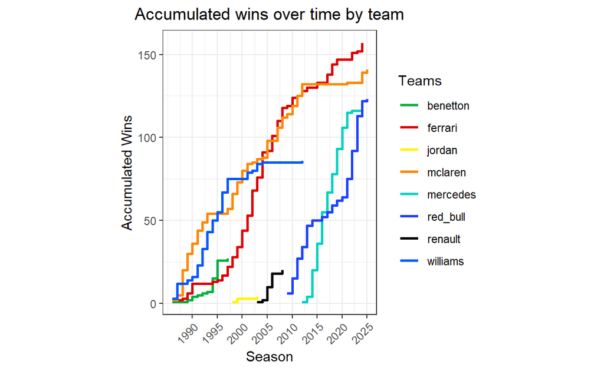

```r
# Accumulating team wins per season and visualizing using a stair-step graph
results_wins_acc <- results_df %>%
  group_by(season, team) %>%
  count(team)

# Adding cumulative wins for each team
results_wins_acc <- results_wins_acc %>%
  group_by(team) %>%
  mutate(cum_n = cumsum(n))

results_wins_acc$season <- as.numeric(results_wins_acc$season)

team_list <- c("ferrari", "mclaren", "mercedes", "red_bull", "williams", "renault", "benetton", "jordan", "brawn", "stewart", "alphatauri")

custom_team_colors <- c(
  "ferrari"   = "#DC0000",
  "mclaren"   = "#FF8700",
  "mercedes"  = "#00D2BE",
  "red_bull"  = "#1E41FF",
  "williams"  = "#005AFF",
  "renault"   = "black",
  "benetton"  = "#00B140",
  "jordan"     = "#FFF500"
)

results_wins_acc2 <- results_wins_acc %>%
  filter(team %in% team_list)

# Plotting the stair-step graph
h = ggplot(results_wins_acc2, aes(x = season, y = cum_n, group = team, color = team)) +
  geom_step(linewidth = 1) +
  theme_bw() +
  theme(aspect.ratio = 4/3,
        axis.text.x = element_text(angle = 45, hjust = 1, vjust = 1),
        plot.title = element_text(hjust = 0.5)
        ) +
  scale_x_continuous(breaks = seq(1990, max(results_wins_acc$season), by = 5),
                     labels = seq(1990, max(results_wins_acc$season), by = 5)) +
  scale_color_manual(values = custom_team_colors) +
  labs(x = "Season", y = "Accumulated Wins", color = "Teams", title = "Accumulated wins over time by team")
h
```

## Analysis

A closer look reveals the rise and plateau of Williams between 2005 and 2010, marking a period of decline after their golden years. In contrast, the most dramatic trend is the meteoric ascent of Mercedes and Red Bull, both of whom amassed over 100 race wins in just over a decade—an achievement that underscores the intensity of modern F1 dominance cycles.

# Visualization2: Wins per Season

Here, we show the number of wins per season for each team using a bar chart. This helps us to compare the performance of teams in different seasons.

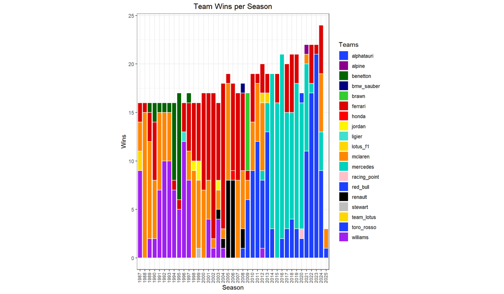

```r
# Visualizing wins per season for each team
custom_team_colors <- c(
  "benetton"     = "darkgreen",
  "mclaren"      = "#FF8700",
  "williams"     = "purple",
  "ferrari"      = "#DC0000",
  "team_lotus"   = "gold",
  "ligier"       = "turquoise",
  "jordan"       = "#FFF500",
  "stewart"      = "grey",
  "renault"      = "black",
  "honda"        = "red",
  "bmw_sauber"   = "navy",
  "toro_rosso"   = "#1E41FF",
  "brawn"        = "limegreen",
  "red_bull"     = "#1E41FF",
  "lotus_f1"     = "gold",
  "mercedes"     = "#00D2BE",
  "alphatauri"   = "#1E41FF",
  "racing_point" = "pink",
  "alpine"       = "darkmagenta"
)
results_wins_acc3 <- results_wins_acc %>%
  filter(season >1986)

j = ggplot(results_wins_acc3, aes(x = as.factor(season), y = n, color = team, fill = team)) +
  geom_bar(stat = "identity", color = "white") +
  theme_bw() +
  theme(aspect.ratio = 4/3,
        plot.title = element_text(hjust = 0.5),
        axis.text.x = element_text(angle = 90, size = 8, vjust = 0.35)) +
        scale_fill_manual(values = custom_team_colors) +
        labs(x = "Season", y = "Wins", fill = "Teams", title = "Team Wins per Season")
j
```

## Analysis

One of the most striking patterns in the graph is the clear succession of team dominance over time. A first glance suggests four distinct eras in Formula 1 history:

Pre-1997 Era: Until the end of the 1997 season, teams like Williams, McLaren, and Benetton led the grid in terms of Grand Prix victories. This period reflects a more competitive balance among top teams, with no single outfit maintaining prolonged dominance.

Ferrari Era (1999–2004): The early 2000s mark the Ferrari golden era, coinciding with Michael Schumacher’s most successful years. During this time, Ferrari asserted near-total control, with consistent wins and multiple championship titles.

Mercedes Era (2014–2020): Following the introduction of the hybrid era, Mercedes emerged as the dominant force, consistently outperforming the competition throughout the 2010s. This period was defined by technical superiority and the rise of Lewis Hamilton’s historic championship run.

Red Bull Era (2021–present): The most recent phase sees Red Bull Racing taking over the spotlight, culminating in a record-breaking 2023 season, where they claimed 21 wins out of 22 races—a feat unmatched in F1 history.

# Visualization3: Heatmap of Race Results

In this section, we visualize the winning teams for the top 25 races using a heatmap. The heatmap shows the distribution of winning teams across different seasons.

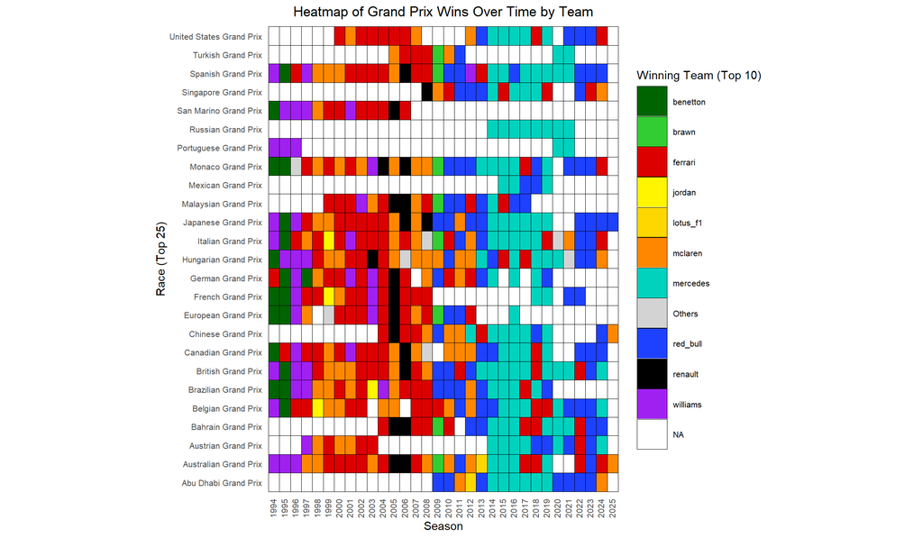

```r
# Preparing data for heatmap visualization
results_gp <- results_df %>%
  group_by(raceName) %>%
  summarise(Count = n())

# Transforming data for heatmap
results_wins_gp2 <- results_df %>%
  select(season, raceName, team) %>%
  spread(season, team)

# Joining with race count data
results_gp_joined <- results_wins_gp2 %>%
  left_join(results_gp, by = "raceName")

# Filtering top 25 races for the heatmap
results_gp_25 <- results_gp_joined %>%
  arrange(desc(Count)) %>%
  top_n(25, wt = Count) %>%
  slice(1:41)

# Pivoting data for heatmap
results_gp_25_long <- results_gp_25 %>%
  pivot_longer(cols = num_range("", 1994:2025),
               names_to = "season",
               values_to = "team")
# Top 10 teams for highlighting in the heatmap
team_counts <- results_gp_25_long %>%
  count(team, sort = TRUE)

top_10_teams <- team_counts %>%
  slice_max(n, n = 11)

# Adding category for top 10 teams
results_gp_25_long <- results_gp_25_long %>%
  mutate(team_category = ifelse(team %in% top_10_teams$team, as.character(team), "Others"))

custom_team_colors <- c(
  "ferrari"   = "#DC0000",
  "brawn"     = "limegreen",
  "mclaren"   = "#FF8700",
  "mercedes"  = "#00D2BE",
  "red_bull"  = "#1E41FF",
  "williams"  = "purple",
  "renault"   = "black",
  "benetton"  = "darkgreen",
  "jordan"    = "#FFF500",
  "lotus_f1"  = "gold",
  "Others"    = "lightgrey",
  "NA"        = "white"
)

# Heatmap plot
a = ggplot(results_gp_25_long, aes(x = season, y = raceName, fill = team_category)) +
  geom_tile(na.rm = TRUE, color = "black", position = "identity") +
  theme_classic() +
  #scale_fill_brewer(palette = "Set3") +
  scale_fill_manual(values = custom_team_colors, na.value = "white") +
  theme(aspect.ratio = 4/3,
        axis.text.y = element_text(size = 8),
        axis.text.x = element_text(angle = 90, size = 8, vjust = 0.35),
        legend.position = "right",
        legend.box = "horizontal",
        legend.text = element_text(size = 8),
        legend.key.size = unit(1, "cm"),
        legend.key.width = unit(1, "cm"),
        axis.line = element_blank(),
        axis.ticks = element_blank(),
        plot.title = element_text(hjust = 0.5)
            )  +
  labs(x = "Season",
       y = "Race (Top 25)",
       fill = "Winning Team (Top 10)",
       title = "Heatmap of Grand Prix Wins Over Time by Team")
a
```

## Analysis

While this heatmap reinforces the established narrative of team dominance across different eras, a deeper look—focusing not just on what’s present but also on what’s absent—reveals the sport’s evolving political and economic landscape.

One notable absence is the Russian Grand Prix, held between 2014 and 2021, which was removed from the calendar following the Russian invasion of Ukraine and the subsequent termination of its contract with F1. This highlights how geopolitical events can directly influence the sport’s global footprint.

The emergence of races in the Middle East, such as the Bahrain and Abu Dhabi Grands Prix, signals the region’s growing involvement and investment in Formula 1 since the mid-2000s—a trend that has only intensified in recent years.

Together, these observations suggest that the race calendar—and by extension, the heatmap—serves not just as a record of sporting events, but as a reflection of F1’s intersection with global politics, economics, and soft power strategies.

# Web Scraping: F1 Team Names and Points

In this section, we use rvest to scrape the names and points of F1 teams from the official website, then visualize the points of each team in a bar chart.

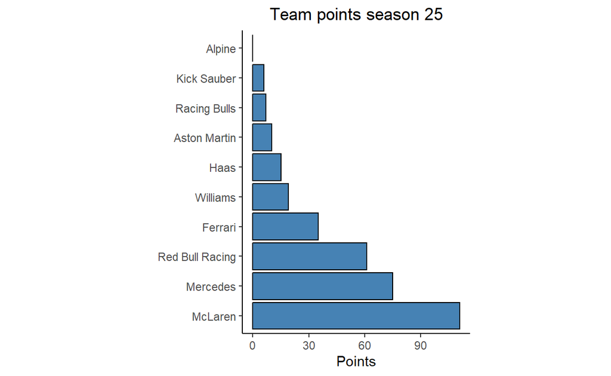

```r
# Read the F1 Teams page
f1_html <- read_html("https://www.formula1.com/en/teams.html")


# Scrape team names
teamnames <- f1_html %>%
  html_elements(".f1-heading") %>%
  html_text2()

indices <- seq(1, 50, by = 5)

teamnames <- teamnames[indices]

# Scrape points
points <- f1_html %>%
  html_elements(".f1-heading-wide") %>%
  html_text2() %>%
  as.numeric()

indices <- seq(1, 20, by = 2)

points <- points[indices]

# Combine into dataframe
f1_df <- tibble(Team = teamnames, Points = points)

# Visualizing team points
u = ggplot(f1_df, aes(x = Points, y = reorder(Team, -Points))) +
  geom_bar(stat = "identity", fill = "steelblue", color = "black") +
  labs(x = "Points", y = "", title = "Team points season 25") +
  theme_classic() +
  theme(aspect.ratio = 4/3,
        plot.title = element_text(hjust = 0.5) )
u
```

# Conclusion

The visualizations provide insights into the performance of Formula 1 teams and drivers from the last 30 years. The stair-step graph and heatmap show the dominance of certain teams over time, while the bar chart helps highlight individual season performances. The scraped data reveals the current performance of teams based on their points in the latest season.

# Sources

F1 Race Results: API from https://api.jolpi.ca/ergast

F1 Team Information: https://www.formula1.com/en/teams.html